# Ứng dụng của mô hình đồ thị có hướng

# 7.1. Mô tả bộ dữ liệu

```r
library(LinRegInteractive)
data(munichrent03)
data <- munichrent03

str(data)
```

```
'data.frame':   2053 obs. of  12 variables:
 $ rent     : num  741 716 528 554 698 ...
 $ rentsqm  : num  10.9 11.01 8.38 8.52 6.98 ...
 $ area     : int  68 65 63 65 100 81 55 79 52 77 ...
 $ rooms    : int  2 2 3 3 4 4 2 3 1 3 ...
 $ yearc    : num  1918 1995 1918 1983 1995 ...
 $ bathextra: Factor w/ 2 levels "no","yes": 1 1 1 2 2 1 2 1 1 1 ...
 $ bathtile : Factor w/ 2 levels "yes","no": 1 1 1 1 1 1 1 1 1 1 ...
 $ cheating : Factor w/ 2 levels "yes","no": 1 1 1 1 1 1 1 1 1 1 ...
 $ district : Factor w/ 25 levels "All-Umenz","Alt-Le",..: 10 10 10 17 17 17 21 21 21 21 ...
 $ location : Ord.factor w/ 3 levels "normal"<"good"<..: 2 2 2 1 2 1 1 1 1 1 ...
 $ upkitchen: Factor w/ 2 levels "no","yes": 1 1 1 1 2 1 1 1 1 1 ...
 $ wwater   : Factor w/ 2 levels "yes","no": 1 1 1 1 1 1 1 1 1 1 ...
```

```r
names(data)
```

```
 [1] "rent"      "rentsqm"   "area"      "rooms"     "yearc"     "bathextra" "bathtile"
 [8] "cheating"  "district"  "location"  "upkitchen" "wwater"
```

```r
summary(data)
```

```
      rent            rentsqm            area           rooms           yearc      bathextra
 Min.   :  77.31   Min.   : 1.470   Min.   : 17.0   Min.   :1.000   Min.   :1918   no :1862
 1st Qu.: 389.95   1st Qu.: 6.800   1st Qu.: 53.0   1st Qu.:2.000   1st Qu.:1948   yes: 191
 Median : 534.30   Median : 8.470   Median : 67.0   Median :3.000   Median :1960
 Mean   : 570.09   Mean   : 8.394   Mean   : 69.6   Mean   :2.598   Mean   :1958
 3rd Qu.: 700.48   3rd Qu.:10.090   3rd Qu.: 83.0   3rd Qu.:3.000   3rd Qu.:1973
 Max.   :1789.55   Max.   :20.090   Max.   :185.0   Max.   :6.000   Max.   :2001

 bathtile   cheating        district      location    upkitchen  wwater
 yes:1673   yes:1878   Neuh-Nymp: 177   normal:1205   no :1903   yes:1981
 no : 380   no : 175   Lud-Isar : 161   good  : 803   yes: 150   no :  72
                       Au-Haid  : 139   top   :  45
                       SchwWest : 137
                       Maxvor   : 132
                       Laim     : 117
                       (Other)  :1190
```

```r
round(data$rent[2]/data$area[2],2)
```

```
[1] 11.01
```

```r
data$rentsqm[2]
```

```
[1] 11.01
```

```r
round(data$rent[100]/data$area[100],2)
```

```
[1] 11.3
```

```r
data$rentsqm[100]
```

```
[1] 11.3
```

```r
# (1) Bỏ biến rent
data$rentsqm <- NULL
```

## Xem các biến rời rạc

Top 7 quận nào có nhiều nhà nhất

```r
head(sort(table(data$district), decreasing = TRUE), 7)
```

```
Neuh-Nymp  Lud-Isar   Au-Haid  SchwWest    Maxvor      Laim   Ram-Per
      177       161       139       137       132       117       115
```

```r
head(sort(table(data$district[data$location %in% c("top", "good")]),
          decreasing = TRUE),7)
```

```
     Maxvor   Neuh-Nymp    Lud-Isar    SchwWest     Au-Haid Schwab-Frei    Trud-Rie
        118         116          97          96          81          50          37
```

Top 7 quận về tiêu chí nhà top+good

```r
head(sort(table(data$district[data$location %in% c("top", "good")]),
          decreasing = TRUE),7)
```

```
     Maxvor   Neuh-Nymp    Lud-Isar    SchwWest     Au-Haid Schwab-Frei    Trud-Rie
        118         116          97          96          81          50          37
```

Bảy quận có nhiều căn hộ nhất là *Neuh-Nymp*, *Lud-Isar*, *Au-Haid*, *SchwWest*, *Maxvor*, *Laim* và *Ram-Per*. Tuy nhiên, khi xét riêng các căn hộ có vị trí tốt (“top” hoặc “good”), quận *Maxvor* vươn lên dẫn đầu, tiếp theo là *Neuh-Nymp* và *Lud-Isar*. Điều này cho thấy *Maxvor* không chỉ có số lượng căn hộ lớn mà còn có tỷ lệ cao các căn hộ ở vị trí tốt. Một số quận như *Schwab-Frei* và *Trud-Rie* dù không nằm trong top về tổng số căn hộ nhưng lại nổi bật về số căn hộ vị trí tốt, phản ánh chất lượng phân bố không gian có thể cao hơn ở những khu vực này.

Xem tiện ích của các căn nhà

```r
library(dplyr)
cols <- c("bathextra", "bathtile", "cheating", "upkitchen", "wwater")
total_n <- nrow(data)
feature_yes_count <- sapply(cols, function(col) {
  sum(data[[col]] == "yes", na.rm = TRUE)
}) |> unname()
feature_summary <- data.frame(
  Feature = cols,
  Count = as.integer(feature_yes_count),
  Percent = round(100 * feature_yes_count / total_n, 1)
)
print(feature_summary)
```

| Feature | Count | Percent |
| --- | --- | --- |
| bathextra | 191 | 9.3 |
| bathtile | 1673 | 81.5 |
| cheating | 1878 | 91.5 |
| upkitchen | 150 | 7.3 |
| wwater | 1981 | 96.5 |

Top 7 quận với số nhà mang các tiện ích cao cấp

```r
head(sort(table(data$district[data$bathextra == "yes" &
    data$cheating == "yes" &  data$upkitchen == "yes" &
    data$wwater == "yes" &data$bathtile=="yes"
    ]), decreasing = TRUE), 7)
```

```
     Neuh-Nymp         Bogenh       Trud-Rie        Au-Haid       Au-Lo-La     Pas-Obmenz
             6              4              3              2              2              2
Th-Ob-Fo-Fu-So
             2
```

Có thể thấy phần lớn căn hộ được trang bị các tiện nghi cơ bản: khoảng 96.5% có nước nóng (*wwater*), 91.5% có hệ thống sưởi trung tâm (*cheating*), và 81.5% có lát gạch trong phòng tắm (*bathtile*). Tuy nhiên, các tiện nghi cao cấp như trang bị nhà bếp cao cấp (*upkitchen*) và phòng tắm nâng cấp (*bathextra*) lại rất hiếm, chỉ chiếm lần lượt 7.3% và 9.3%. Khi xét các căn hộ có đầy đủ cả năm tiện nghi này, chỉ có một số ít nằm rải rác ở các quận như *Neuh-Nymp*, *Bogenh*, *Trud-Rie* và *Au-Haid*, mỗi nơi chỉ có từ 2 đến 6 căn hộ đạt chuẩn, cho thấy các căn hộ cao cấp là rất hiếm trong bộ dữ liệu.

## Xem các biến liên tục

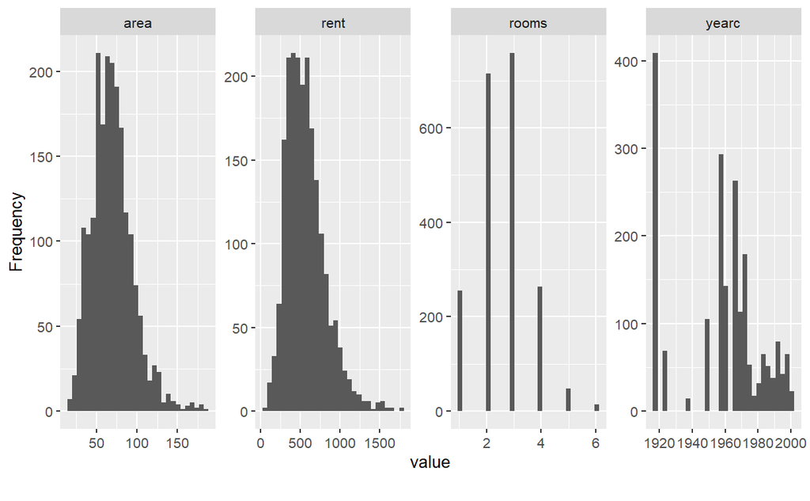

```r
#pdf("7.1.pdf", width = 6, height = 3)  # đơn vị là inch
library(DataExplorer)
plot_histogram(data)
```

```r
#dev.off()
```

```r
shapiro.test(data$rent)
```

```
    Shapiro-Wilk normality test

data:  data$rent
W = 0.94478, p-value < 2.2e-16
```

```r
shapiro.test(data$area)
```

```
    Shapiro-Wilk normality test

data:  data$area
W = 0.96226, p-value < 2.2e-16
```

Biến year không hẳn là liên tục vì xét theo từng năm rời rạc. Tương tự, biến rooms cũng vậy vì thống kê số phòng chỉ là các con số rời rạc.

```r
table(data$room)
```

```
  1   2   3   4   5   6
255 715 759 263  47  14
```

```r
table(data$yearc)
```

```
  1918   1924   1939   1948   1957 1957.5   1960   1966   1967   1968   1969   1970   1971   1972
   409     69     14    105    225     68    143    228     35     23     44     46     35     89
  1973   1974   1975   1976   1977   1978   1979   1980   1981   1982   1983   1984   1985   1986
    55     30     16      7      6      5      6     17     15      8     40     17     20     11
  1987   1988   1989   1990   1991   1992   1993   1994   1995   1996   1997   1998 1998.5   1999
    20     13     15     10     14     24     41     13      9     20     12     14     32      7
  2000   2001
    18      5
```

# 7.2. Mục tiêu

Phân tích các yếu tố Tiện nghi, Vị trí và Giá Thuê nhà tại thành phố Munich, bằng cách mô hình hóa các mối quan hệ bằng mô hình đồ thị có hướng.

```r
names(data[-c(1,2,3,4,8,9)])
```

```
[1] "bathextra" "bathtile"  "cheating"  "upkitchen" "wwater"
```

Đồng thời hai biến year và rooms như đã phân tích ở trên cũng có thể tiếp cận bằng cách rời rạc,v à số levels là rất lơn, ta cần thực hiện việc rút gọn số levels lại. Chính vì vậy, ta sẽ thực hiện phương pháp rời rạc hóa các biến liên tục và mô hình hóa các biến rời rạc thành một mô hình đồ thị có hướng rời rạc.

# 7.3. Tiền xử lý dữ liệu

# Thư viện

```r
library(gRbase)
library(Rgraphviz)
library(bnlearn)
library(gRain)
library(ggm)
library(igraph)
```

## Xử lý rooms và location

Ta sẽ xem số lượng phòng từ 1 đến 6 chính là levels và chuyển rooms thành factor, còn biến location chuyển từ ordinal factor thành factor.

```r
data$rooms <- as.factor(data$rooms)
data$location <- as.factor(as.character(data$location))
```

## Xử lý year

```r
#Lam tron nam
data$yearc <- round(data$yearc)
#Phan nhom
data$year_group <- cut(data$yearc,
  breaks = c(1917, 1959, 1969, 1989, 2001),
  labels = c("1918-1959", "1960-1969", "1970-1989", "1990-2001"),right = TRUE)
#Kiem tra lai so dong
length(data$year_group) == nrow(data)
```

```
[1] TRUE
```

## Xử lý district

Để xử lý biến này với mục tiêu rút gọn số levels và giữ được nhiều thông tin từ bộ dữ liệu, trước hết ta sẽ bố trí các quận vào các khu vực dựa vào: mật độ số căn hộ và vị trí địa lý.

Tổng số căn nhà trong mỗi quận

```r
district_counts <- sort(table(data$district), decreasing = TRUE)
district_counts
```

```
     Neuh-Nymp       Lud-Isar        Au-Haid       SchwWest         Maxvor           Laim
           177            161            139            137            132            117
       Ram-Per Th-Ob-Fo-Fu-So         Bogenh      Ugies-Har    Schwab-Frei        Mil-AmH
           115            106             98             82             78             70
     Send-West         Obgies           Send       Schwanth        BamLaim           Moos
            69             67             66             62             60             58
    Pas-Obmenz            Had         Alt-Le       Trud-Rie       Feld-Has       Au-Lo-La
            56             50             43             43             29             24
     All-Umenz
            14
```

```r
district_ordered <- names(district_counts)
```

Khu vực 1:

```r
area1_index <- c(1, 2, 3, 4, 5, 6, 9 ,11, 12, 16, 21)
district_ordered[area1_index]
```

```
 [1] "Neuh-Nymp"   "Lud-Isar"    "Au-Haid"     "SchwWest"    "Maxvor"      "Laim"
 [7] "Bogenh"      "Schwab-Frei" "Mil-AmH"     "Schwanth"    "Alt-Le"
```

Khu vực 2:

```r
area2_index <- c(7, 8, 10, 13, 14, 15, 17, 20, 22)
district_ordered[area2_index]
```

```
[1] "Ram-Per"        "Th-Ob-Fo-Fu-So" "Ugies-Har"      "Send-West"      "Obgies"
[6] "Send"           "BamLaim"        "Had"            "Trud-Rie"
```

Khu vực 3:

```r
area3_index <- setdiff(1:length(district_ordered), c(area1_index, area2_index))
district_ordered[area3_index]
```

```
[1] "Moos"       "Pas-Obmenz" "Feld-Has"   "Au-Lo-La"   "All-Umenz"
```

```r
district_group_info <- data.frame(district = district_ordered,
                                  group = NA)
district_group_info$group[area1_index] <- "Area1"
district_group_info$group[area2_index] <- "Area2"
district_group_info$group[area3_index] <- "Area3"
data$district_group <-
  district_group_info$group[match(data$district, district_group_info$district)]
data$district_group <- as.factor(data$district_group)
sum(table(data$district_group)) == nrow(data)
```

```
[1] TRUE
```

## Rời rạc hóa rent và area

```r
#discretize continuous data into factors.
#discretize(data, method = c("quantile","interval","hartemink"), breaks = )
#discretize(data, method = "hartemink", breaks = , ibreaks = , idisc = )
```

```r
#Chuan bi bo du lieu cho roi rac hoa
data_bn <- data[, !(names(data) %in% c("yearc", "district"))]
data_bn$rent <- as.numeric(data_bn$rent)
data_bn$area <- as.numeric(data_bn$area)
#Roi rac hoa bang "hartemink"
data_disc <- discretize(data_bn, method = "hartemink",breaks = 3,ibreaks = 60,
                        idisc = "quantile")
str(data_disc)
```

```
'data.frame':   2053 obs. of  11 variables:
 $ rent          : Factor w/ 3 levels "[77.31,406.132]",..: 3 3 2 2 3 3 1 2 2 1 ...
 $ area          : Factor w/ 3 levels "[17,44]","(44,78]",..: 2 2 2 2 3 3 2 3 2 2 ...
 $ rooms         : Factor w/ 6 levels "1","2","3","4",..: 2 2 3 3 4 4 2 3 1 3 ...
 $ bathextra     : Factor w/ 2 levels "no","yes": 1 1 1 2 2 1 2 1 1 1 ...
 $ bathtile      : Factor w/ 2 levels "yes","no": 1 1 1 1 1 1 1 1 1 1 ...
 $ cheating      : Factor w/ 2 levels "yes","no": 1 1 1 1 1 1 1 1 1 1 ...
 $ location      : Factor w/ 3 levels "good","normal",..: 1 1 1 2 1 2 2 2 2 2 ...
 $ upkitchen     : Factor w/ 2 levels "no","yes": 1 1 1 1 2 1 1 1 1 1 ...
 $ wwater        : Factor w/ 2 levels "yes","no": 1 1 1 1 1 1 1 1 1 1 ...
 $ year_group    : Factor w/ 4 levels "1918-1959","1960-1969",..: 1 4 1 3 4 3 1 1 1 1 ...
 $ district_group: Factor w/ 3 levels "Area1","Area2",..: 1 1 1 2 2 2 2 2 2 2 ...
```

# 7.4. Tiêu chí đánh giá và chọn mô hình

# 7.5. Học cấu trúc DAG

```r
# boot.strength(data = , R = 300,
#               algorithm = c("pc.stable","hc","mmhc"),
#               algorithm.args = list())
```

## Bootstrap 500 lần

```r
set.seed(42)
boot_pc <- boot.strength(data = data_disc, R = 500, algorithm = "pc.stable",
                         algorithm.args = list(test = "mi"))
boot_hc <- boot.strength(data = data_disc, R = 500, algorithm = "hc",
                         algorithm.args = list(score = "bic"))
boot_mmhc <- boot.strength(data = data_disc, R = 500, algorithm = "mmhc")
```

## Trung bình hóa

```r
avgnet_pc <- averaged.network(boot_pc[boot_pc$direction>=0.5,],
                              threshold = 0.85)
avgnet_hc <- averaged.network(boot_hc[boot_hc$direction>=0.5,],
                              threshold = 0.85)
avgnet_mmhc <- averaged.network(boot_mmhc[boot_mmhc$direction>=0.5,],
                                threshold = 0.55)
```

## Tính các tiêu chí

```r
mean_strength <- function(strength, DAG)
  {arcs_net <- arcs(DAG)
  matched_strength <- strength[
    apply(strength[, c("from", "to")], 1, function(x)
      any(apply(arcs_net, 1, function(y) all(x == y)))
    ),]
  mean(matched_strength$strength)
  }
results <- data.frame(
  Algorithm = c("pc.stable", "hc", "mmhc"),
  BIC = c(score(avgnet_pc,   data = data_disc, type = "bic"),
          score(avgnet_hc,   data = data_disc, type = "bic"),
          score(avgnet_mmhc, data = data_disc, type = "bic")),
  Egdes=c(dim(arcs(avgnet_pc))[1],
          dim(arcs(avgnet_hc))[1],
          dim(arcs(avgnet_mmhc))[1]),
  Mean_Strength = c(mean_strength(boot_pc,   avgnet_pc),
                    mean_strength(boot_hc,   avgnet_hc),
                    mean_strength(boot_mmhc, avgnet_mmhc))
  )
results
```

| Algorithm | BIC | Egdes | Mean_Strength |
| --- | --- | --- | --- |
| pc.stable | -14943.23 | 4 | 0.9970000 |
| hc | -14191.93 | 9 | 0.9815556 |
| mmhc | -14290.91 | 7 | 0.9734286 |

Mỗi mô hình sẽ có một sự đánh đổi trong các tiêu chí, không mô hình nào là vượt trội ở cả 3 tiêu chí. Ta sẽ cần phải dựa vào khả năng diễn giải của các cấu trúc DAG.

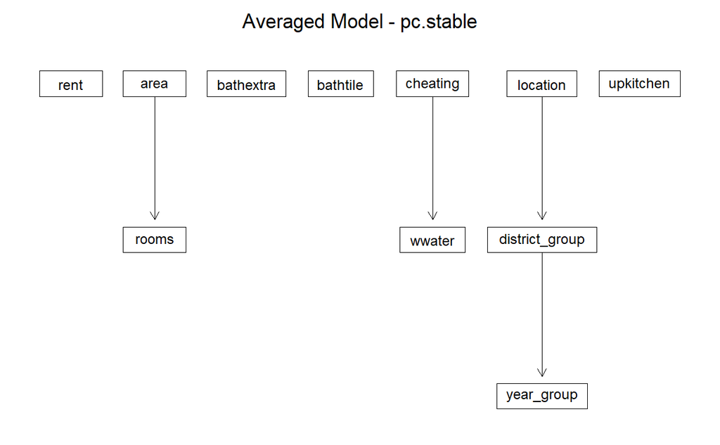

```r
library(Cairo)
#CairoPDF("models_alg.pdf", family = "Arial", width = 7, height = 5)
graphviz.plot(avgnet_pc, main = "Averaged Model - pc.stable")
```

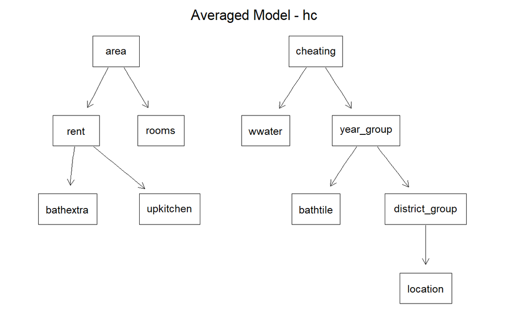

```r
graphviz.plot(avgnet_hc, main = "Averaged Model - hc")
```

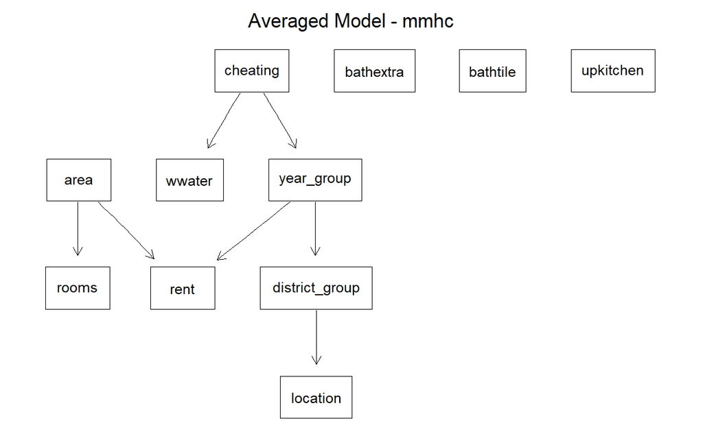

```r
graphviz.plot(avgnet_mmhc, main = "Averaged Model - mmhc")
```

```r
#dev.off()
```

##Giảm ngưỡng về 75%

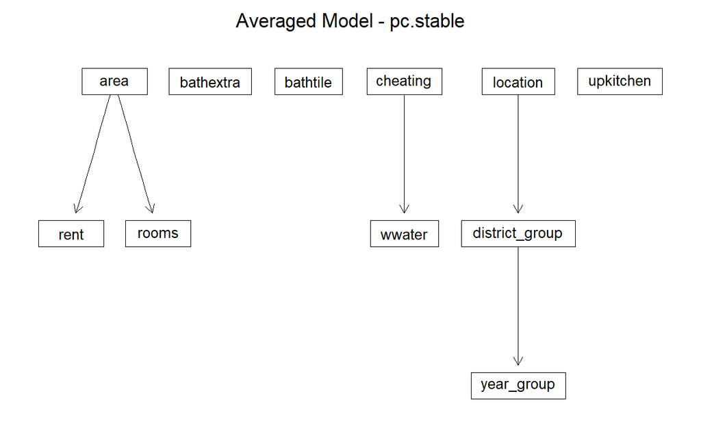

```r
avgnet_pc <- averaged.network(boot_pc[boot_pc$direction>=0.5,],
                              threshold = 0.75)
avgnet_hc <- averaged.network(boot_hc[boot_hc$direction>=0.5,],
                              threshold = 0.75)
avgnet_mmhc <- averaged.network(boot_mmhc[boot_mmhc$direction>=0.5,],
                                threshold = 0.75)
graphviz.plot(avgnet_pc, main = "Averaged Model - pc.stable")
```

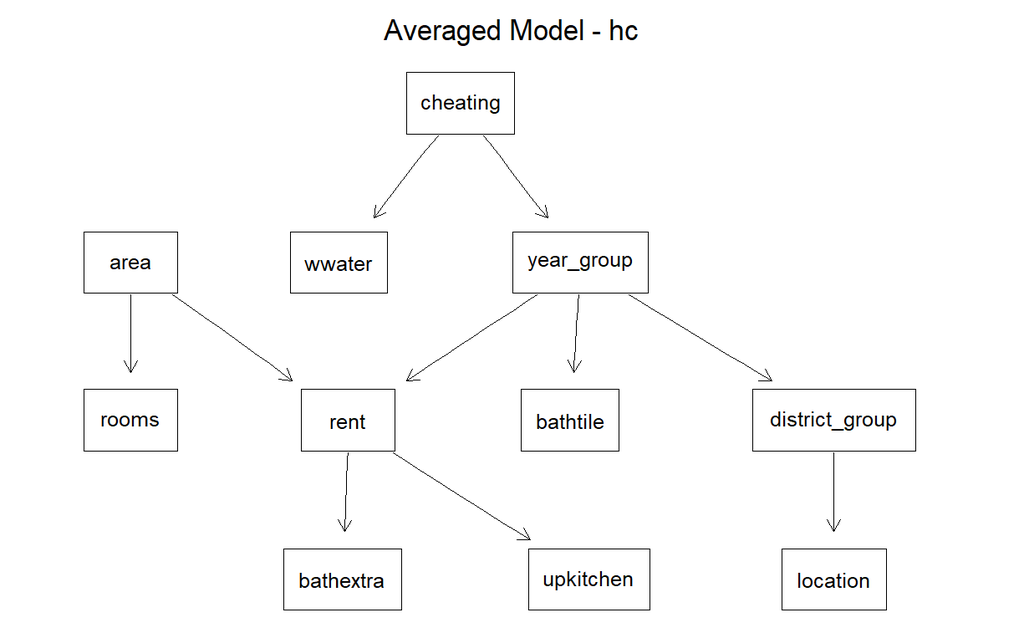

```r
graphviz.plot(avgnet_hc, main = "Averaged Model - hc")
```

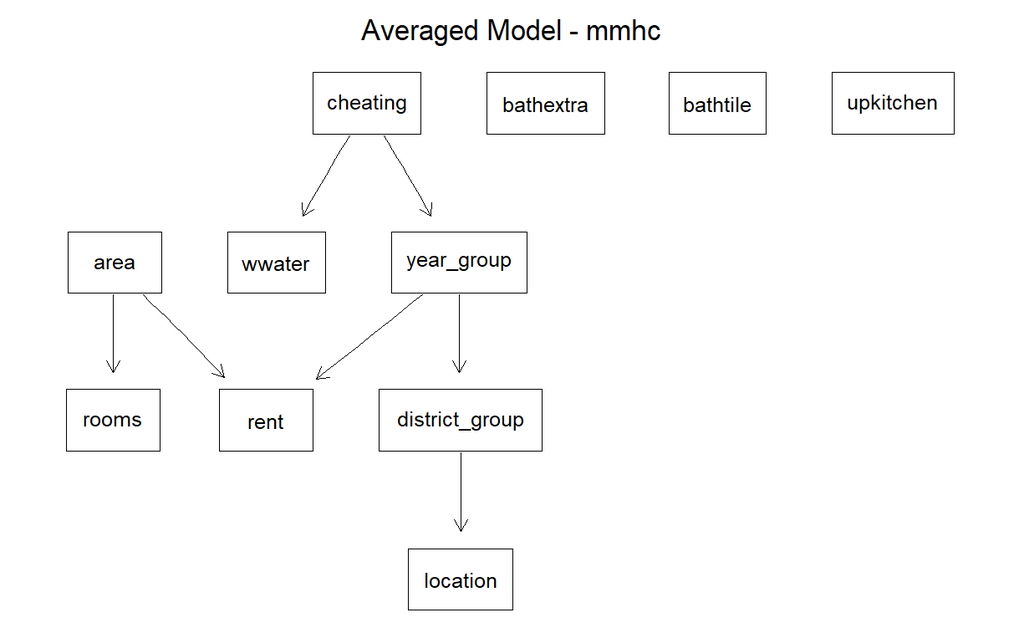

```r
graphviz.plot(avgnet_mmhc, main = "Averaged Model - mmhc")
```

Xem khả năng diễn giải

```r
#library(Cairo)
#CairoPDF("models_alg_1.pdf", family = "Arial", width = 7, height = 5)
# graphviz.plot(avgnet_pc, main = "Averaged Model - pc.stable")
# graphviz.plot(avgnet_hc, main = "Averaged Model - hc")
# graphviz.plot(avgnet_mmhc, main = "Averaged Model - mmhc")
#dev.off()
```

Tính lại các tiêu chí

```r
results <- data.frame(
  Algorithm = c("pc.stable", "hc", "mmhc"),
  BIC = c(score(avgnet_pc,   data = data_disc, type = "bic"),
          score(avgnet_hc,   data = data_disc, type = "bic"),
          score(avgnet_mmhc, data = data_disc, type = "bic")),
  Egdes=c(dim(arcs(avgnet_pc))[1],
          dim(arcs(avgnet_hc))[1],
          dim(arcs(avgnet_mmhc))[1]),
  Mean_Strength = c(mean_strength(boot_pc,   avgnet_pc),
                    mean_strength(boot_hc,   avgnet_hc),
                    mean_strength(boot_mmhc, avgnet_mmhc))
  )
results
```

| Algorithm | BIC | Egdes | Mean_Strength |
| --- | --- | --- | --- |
| pc.stable | -14450.33 | 5 | 0.9664000 |
| hc | -14149.04 | 10 | 0.9624000 |
| mmhc | -14290.91 | 7 | 0.9734286 |

## Chốt mô hình hc và diễn giải

Chọn mô hình cuối cùng là hc (trung bình hóa ngưỡng 75%)

```r
final_mod_dag=averaged.network(boot_hc[boot_hc$direction>=0.5,],threshold = 0.75)
```

Diễn giải.

# 7.6. Học tham số mô hình

```r
fit = bn.fit(final_mod_dag, data = data_disc, method = "mle")
```

Kiểm tra có xác suất nào không ước lượng được hay không

```r
has_na <- sapply(fit, function(node) any(is.na(unlist(node$prob))))
names(has_na)[has_na]
```

```
character(0)
```

# 7.7. Suy diễn

```r
gr_fit <- as.grain(fit)
```

#Giá thuê

1. Giá thuê bị ảnh hưởng trực tiếp và gián tiếp bởi những yếu tố nào?

Mối quan hệ trực tiếp:

```r
parents(fit,"rent")
```

```
[1] "area"       "year_group"
```

```r
children(fit,"rent")
```

```
[1] "bathextra" "upkitchen"
```

Mối quan hệ gián tiếp: rooms thông qua area district_group và location thông qua year_group cheating và wwater thông qua year_group bathtile thông qua year_group

2. Phân tích

```r
dsep(fit,"district_group","bathextra","rent")
```

```
[1] TRUE
```

```r
data_disc[c(18),][c(2,4,7:8,11,1)]
```

|  | area | bathextra | location | upkitchen | district_group | rent |
| --- | --- | --- | --- | --- | --- | --- |
| 18 | (78,185] | no | good | no | Area1 | (687.072,1789.55] |

```r
data_disc[c(114),][c(2,4,7:8,11,1)]
```

|  | area | bathextra | location | upkitchen | district_group | rent |
| --- | --- | --- | --- | --- | --- | --- |
| 114 | (78,185] | no | top | no | Area1 | (687.072,1789.55] |

```r
dsep(fit,"rent","rooms","area")
```

```
[1] TRUE
```

```r
dsep(fit,"rent","location","year_group")
```

```
[1] TRUE
```

```r
dsep(fit,"rent","district_group","year_group")
```

```
[1] TRUE
```

```r
dsep(fit,"rent","cheating","year_group")
```

```
[1] TRUE
```

```r
dsep(fit,"area","year_group")
```

```
[1] TRUE
```

```r
dsep(fit,"rooms","district_group")
```

```
[1] TRUE
```

```r
dsep(fit,"area","cheating")
```

```
[1] TRUE
```

```r
dsep(fit,"area","location")
```

```
[1] TRUE
```

```r
dsep(fit,"area","year_group","rent")
```

```
[1] FALSE
```

```r
dsep(fit,"rooms","district_group","rent")
```

```
[1] FALSE
```

```r
dsep(fit,"area","cheating","rent")
```

```
[1] FALSE
```

```r
dsep(fit,"area","location","rent")
```

```
[1] FALSE
```

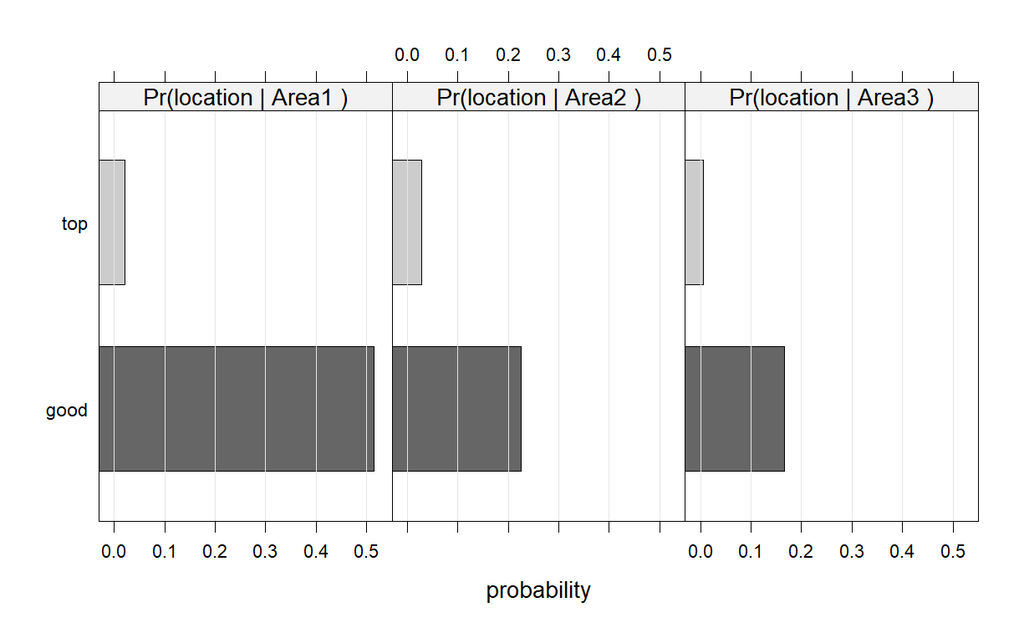

```r
library(lattice)
districts <- levels(data_disc$district_group)
loc_levels <- c("good", "top")
distr <- do.call(rbind, lapply(districts, function(d) {
  prob <- querygrain(setEvidence(gr_fit, evidence = list(district_group = d)), nodes = "location")$location
  data.frame(District = d, Location = loc_levels, Prob = as.numeric(prob[loc_levels]))
}))
barchart(Location ~ Prob | District, data = distr,
         layout = c(3, 1), xlab = "probability",
         strip = strip.custom(factor.levels = paste("Pr(location |", districts, ")")),
         col = c("gray40", "gray80"),
         panel = function(...) {
           panel.barchart(...)
           panel.grid(h = 0, v = -1)
         })
```

```r
#CairoPDF("locationtopgood_district.pdf", family = "Arial", width = 7, height = 5)
#dev.off()
```

```r
levels(data_disc$rent)
```

```
[1] "[77.31,406.132]"   "(406.132,687.072]" "(687.072,1789.55]"
```

```r
cpquery(fit,event = rent %in% c("[77.31,406.132]","(406.132,687.072]"),
        evidence = (district_group == "Area1"),
        n = 10^5)
```

```
[1] 0.739129
```

```r
cpquery(fit,event = rent %in% c("[77.31,406.132]","(406.132,687.072]"),
        evidence = (district_group == "Area2"),
        n = 10^5)
```

```
[1] 0.7273798
```

```r
cpquery(fit,event = rent %in% c("[77.31,406.132]","(406.132,687.072]"),
        evidence = (district_group == "Area3"),
        n = 10^5)
```

```
[1] 0.7249213
```

```r
# # So can nha phan khuc gia thap
# table(data_disc$district_group[data_disc$rent == "[77.31,406.132]"|data_disc$rent =="(406.132,687.072]"])
# # So can nha moi khu vuc
# table(data_disc$district_group)
```

```r
querygrain(setEvidence(gr_fit, nodes = "cheating", states = "yes"),nodes = c("wwater"),type = "joint")
```

```
wwater
        yes          no
0.994142705 0.005857295
```

```r
levels(data_disc$year_group)
```

```
[1] "1918-1959" "1960-1969" "1970-1989" "1990-2001"
```

```r
querygrain(setEvidence(gr_fit, nodes = "year_group", states = "1918-1959"),
           nodes = c("cheating"),type = "joint")["yes"]
```

```
      yes
0.8123596
```

```r
querygrain(setEvidence(gr_fit, nodes = "year_group", states = "1960-1969"),
           nodes = c("cheating"),type = "joint")["yes"]
```

```
      yes
0.9830867
```

```r
querygrain(setEvidence(gr_fit, nodes = "year_group", states = "1990-2001"),
           nodes = c("cheating"),type = "joint")["yes"]
```

```
yes
  1
```

```r
levels(data_disc$rent)
```

```
[1] "[77.31,406.132]"   "(406.132,687.072]" "(687.072,1789.55]"
```

```r
querygrain(setEvidence(gr_fit, nodes = "year_group", states = "1918-1959"),
           nodes = c("cheating"),type = "joint")["yes"]
```

```
      yes
0.8123596
```

```r
querygrain(setEvidence(gr_fit, nodes = "year_group", states = "1960-1969"),
           nodes = c("cheating"),type = "joint")["yes"]
```

```
      yes
0.9830867
```

```r
querygrain(setEvidence(gr_fit, nodes = "year_group", states = "1990-2001"),
           nodes = c("cheating"),type = "joint")["yes"]
```

```
yes
  1
```

```r
querygrain(setEvidence(gr_fit, nodes = "rent", states = "[77.31,406.132]"),
           nodes = c("upkitchen", "bathextra"), type = "joint")["yes","yes"]
```

```
[1] 0.0002066579
```

```r
querygrain(setEvidence(gr_fit, nodes = "rent", states = "(406.132,687.072]"),
           nodes = c("upkitchen", "bathextra"), type = "joint")["yes","yes"]
```

```
[1] 0.003566025
```

```r
querygrain(setEvidence(gr_fit, nodes = "rent", states = "(687.072,1789.55]"),
           nodes = c("upkitchen", "bathextra"), type = "joint")["yes","yes"]
```

```
[1] 0.03537748
```

```r
querygrain(setEvidence(gr_fit, nodes = "rent", states = "(687.072,1789.55]"),
           nodes = c("upkitchen"), type = "joint")["yes"]
```

```
      yes
0.1514599
```

```r
querygrain(setEvidence(gr_fit, nodes = "rent", states = "(687.072,1789.55]"),
           nodes = c("bathextra"), type = "joint")["yes"]
```

```
      yes
0.2335766
```